# DATA 308: Homework 4

Inference with simple linear regression

Author

Dylan Wikel

```r
library(ggfortify)
library(hellodatascience)
library(broom)
library(tidyverse)
```

# Instructions

For this activity we will:

1. Specify a simple linear regression model to investigate the relationship of interest.
2. Specify our hypotheses.
3. Fit the proposed model.
4. Assess suitability of our proposed model.
5. Report our statistical decision, conclusion in context, and estimate of the association, indicating any model sensitivity.

# Investigation

## Research question

The [American Time Use Survey (ATUS)](https://www.bls.gov/tus/overview.htm) provides estimates about how Americans spend their time. The American Time Use Survey is conducted by the U.S. Census Bureau for the Bureau of Labor Statistics. ATUS respondents are randomly selected from households that have completed their final interview for the Current Population Survey, and only one person is selected from each participating household.

> Among full-time college or university students represented in the 2024 ATUS data who were employed part time, is mean time spent sleeping on the diary day linearly associated with usual weekly earnings?

Let’s use the weekly earnings as our response variable.

## 1. Our model

State your proposed theoretical population model.

### Response

$$Y_i = \beta_0 + \beta_1X_i + \epsilon_i$$

## 2. Hypotheses

State your hypotheses.

### Response

$$\text{Null Hypothesis: } H_0 = \beta_1$$
$$\text{Alternative Hypothesis: } H_a \ne \beta_1$$

## Data

We will use the `atus_college` dataset from the `hellodatascience` R package to investigate our research question. Start by entering `?atus_college` into the Console to bring up the help documentation, then run the code chunk below to glimpse your dataset.

Notice I am filtering the original `atus_college` dataset to only include people enrolled in college full time and working part time. I am then dropping an rows missing either `weekly_earnings` or `sleep_time`. For this assignment you should use the `atus_college_workers` dataset.

```r
data("atus_college")

atus_college_workers <- atus_college |>
  filter(enrollment == "Full Time" & employment == "Part Time") |>
  drop_na(weekly_earnings, sleep_time)

glimpse(atus_college_workers)
```

```
Rows: 74
Columns: 13
$ employment        <fct> Part Time, Part Time, Part Time, Part Time, Part Tim…
$ age               <dbl> 22, 21, 25, 18, 28, 21, 22, 21, 18, 35, 22, 20, 22, …
$ enrollment        <fct> Full Time, Full Time, Full Time, Full Time, Full Tim…
$ weekly_earnings   <dbl> 561.25, 100.00, 300.00, 425.00, 500.00, 54.00, 2500.…
$ household_size    <dbl> 2, 4, 3, 4, 2, 5, 3, 6, 4, 3, 2, 3, 7, 6, 2, 4, 1, 3…
$ time_alone        <dbl> 357, 22, 455, 285, 696, 420, 330, 520, 265, 615, 624…
$ sleep_time        <dbl> 470, 660, 765, 660, 360, 640, 580, 540, 665, 450, 42…
$ work_time         <dbl> 0, 0, 0, 0, 0, 0, 0, 240, 0, 0, 20, 0, 330, 385, 0, …
$ degree_class_time <dbl> 238, 0, 0, 0, 150, 0, 0, 195, 0, 375, 0, 0, 180, 160…
$ shopping_time     <dbl> 0, 0, 0, 0, 0, 90, 0, 0, 0, 0, 30, 0, 0, 0, 0, 0, 0,…
$ lunch_break_time  <dbl> 20, 115, 50, 15, 30, 60, 60, 20, 20, 60, 23, 60, 45,…
$ sports_time       <dbl> 0, 30, 0, 0, 50, 0, 0, 0, 0, 0, 0, 0, 0, 0, 0, 60, 0…
$ religious_time    <dbl> 0, 0, 0, 0, 0, 0, 0, 0, 0, 0, 0, 0, 0, 0, 0, 0, 0, 0…
```

## 3. Fitting your model

Fit your proposed model.

### Response

```r
atus_model <- lm(weekly_earnings ~ sleep_time, data = atus_college_workers)

atus_model
```

```
Call:
lm(formula = weekly_earnings ~ sleep_time, data = atus_college_workers)

Coefficients:
(Intercept)   sleep_time
  386.01015      0.08382
```

## Viewing estimated model

Use `tidy()` to display the estimated coefficients, their standard errors, test statistics, p-values, and 95% confidence intervals. We have used `summary()` and `confint()` in the past, this is a different option that shows us all the results we want together.

### Response

```r
# Replace NULL with the fitted model
tidy(
  atus_model,
  conf.int = TRUE
)
```

```
# A tibble: 2 × 7
  term        estimate std.error statistic p.value conf.low conf.high
  <chr>          <dbl>     <dbl>     <dbl>   <dbl>    <dbl>     <dbl>
1 (Intercept) 386.       251.        1.54    0.129 -115.      887.
2 sleep_time    0.0838     0.453     0.185   0.854   -0.818     0.986
```

## Estimate model

Write out the estimated regression equation.

### Response

$$\hat Y \text{ Weekly Earnings}_i = 386.01 + 0.084 \times \text {Sleep Time}_i$$

## 4. Assessing model suitability

We will assess each model condition and then investigate whether the fitted model is sensitive to unusual observations.

### 1. Independence

Are you concerned that the independence condition is not satisfied?

AKA: Based on the available information in the help documentation, is it reasonable to treat the observations as independent? Explain what evidence supports your assessment and identify any limitations in the available study information.

#### Response

Information about the sample is limited, however the data comes from a random sample of individuals representing their households across the U.S. who responded to the ATUS survey. Based on this, I think that the independence condition is satisfied. A primary concern is that the people selected for the survey agreed to be apart of the study representing a household as a single individual of the household. The subset sample size (n = 74) might also be too small to accurately represent college workers in the U.S.

### Diagnostic plots

Generate the four standard diagnostic plots.

#### Response

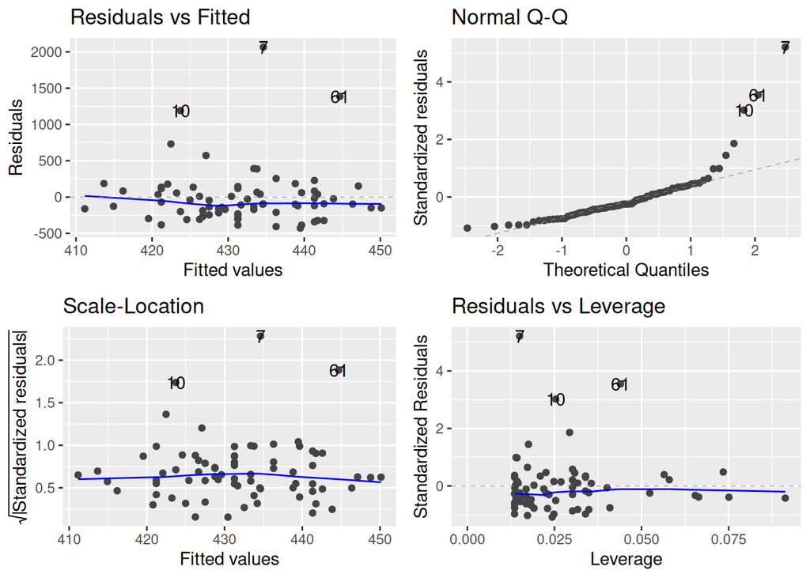

```r
autoplot(atus_model)
```

### 2. Linearity

Are you concerned that the linearity condition is not satisfied?

#### Response

Upon inspection of the Residuals vs. Fitted plot, the data appear to be fairly linear following a linear pattern around 0.

### 3. Constant variance

Are you concerned that the constant variance condition is not satisfied?

#### Response

The variance appears constant aside from the extreme outlying data points 7, 10, and 61. Examining the shape, there is also some slight fanning. Based on the extreme outliers and mild fanning behavior, I do not think that the constant variance condition is not satisfied.

### 4. Normality

Are you concerned that the normality condition is not satisfied?

#### Response

The data appear fairly normal following the Q-Q plot line very closely. However, there are some data points that trail off at the end that do not appear to follow the normality line. The data do not appear normal upon visual inspection of the Q-Q plot. Further investigation into the outliers is necessary.

### Sensitivity to unusual observations

Use the residuals-versus-leverage plot to identify any observations that may have relatively high influence. If you identify a potentially influential observation, use slice() to inspect it. Then refit the model without that observation and compare the results. Is the conclusion sensitive to that observation?

#### Response

```r
atus_college_workers |>
  slice(7)
```

```
# A tibble: 1 × 13
  employment   age enrollment weekly_earnings household_size time_alone
  <fct>      <dbl> <fct>                <dbl>          <dbl>      <dbl>
1 Part Time     22 Full Time             2500              3        330
# ℹ 7 more variables: sleep_time <dbl>, work_time <dbl>,
#   degree_class_time <dbl>, shopping_time <dbl>, lunch_break_time <dbl>,
#   sports_time <dbl>, religious_time <dbl>
```

```r
atus_model_minus7 <- lm(weekly_earnings ~ sleep_time,
                        data = slice(atus_college_workers, -7))

tidy(atus_model_minus7)
```

```
# A tibble: 2 × 5
  term         estimate std.error statistic p.value
  <chr>           <dbl>     <dbl>     <dbl>   <dbl>
1 (Intercept) 408.        200.       2.04    0.0452
2 sleep_time   -0.00756     0.360   -0.0210  0.983
```

I identified 3 potentially concerning data points 7, 10, and 61 after visually inspecting the diagnostic plots. After testing the model on each individual data point, data point 7 appears to have the greatest effect on the model, changing the slope from positive to negative after removing it. I inspected the data further and found that data point 7 makes an unusually large amount of money when compared to the rest of the dataset, followed by data points 10 and 61.

## 5. Reporting your results

State your statistical decision with a significance level of 0.05.

### Response

Fail to reject $H_0$ as we have a p-value greater than $0.05$ where $p = 0.8535800$.

## Conclusion in context

State your conclusion in context. Recall:

- One sentence should be your conclusion for the hypothesis test, with the p-value provided in parentheses.
- The second sentence should be your estimate and 95% confidence interval interpreted in context.
- The third should mention if your results were especially sensitive to an extreme observation, and provide insight into that observation.